A Text Analysis of Bob Dylan Songs

By Genesis Data

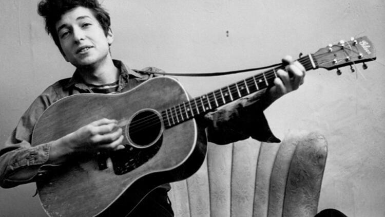

“So thank you for writing the best songs  
Thank you for righting a few wrongs  
You’re a savage gift on a wayward bus  
But you stepped down and you sang to us  
And get you down to the harbor now  
Most of the sour grapes are gone from the bough  
Ghosts of Johanna will visit you there  
And the winds of the old days will blow through your hair”

**Bob Dylan** (born Robert Allen Zimmerman; May 24, 1941) is an American singer-songwriter, author and visual artist. Often regarded as one of the greatest songwriters of all time, Dylan has been a major figure in popular culture during a career spanning nearly 60 years. Much of his most celebrated work dates from the 1960s, when songs such as “Blowin’ in the Wind” (1963) and “The Times They Are a-Changin’” (1964) became anthems for the civil rights and anti-war movements. His lyrics during this period incorporated a range of political, social, philosophical, and literary influences, defying pop music conventions and appealing to the burgeoning counterculture.

He was awarded **Nobel Prize in Literature** *“for having created new poetic expressions within the great American song tradition” (Wikipedia)*

Let’s make a text analysis using his songs!

**1.Importing Required the Libraries**

```r
library(pdftools)
library(dplyr)
library(tidytext)
library(readtext)
library(tm)
library(ggplot2)
library(tidyr)
library(reshape2)
library(wordcloud2)
data(stop_words)
```

**2.Inspect the lyrics & divide them into words (i.e. tokens)**

```r
#Inspect the book

book <- pdftools::pdf_text("http://www.passwordpublish.co.uk/Publishing%20ebook/dylanlyrics.pdf")
dylan_words <- tibble(line = 1:length(book), text = book)

lyrics <- dylan_words %>%
  unnest_tokens(word, text) %>%
  anti_join(stop_words) %>%
  count(word, sort = TRUE)

#Further delete the words like "he's", "i'm", "you're":

lyrics <- lyrics[-c(1,2, 3, 4, 5, 7, 9, 12, 13, 14, 16, 24), ]

#Hence, the most frequently used words by Bob Dylan
lyrics
```

```
## # A tibble: 7,472 x 2
##    word      n
##    <chr> <int>
##  1 love    336
##  2 time    326
##  3 baby    250
##  4 night   225
##  5 day     166
##  6 mind    152
##  7 eyes    147
##  8 heart   145
##  9 lord    143
## 10 world   132
## # ... with 7,462 more rows
```

**3.Visualize the frequently used words**

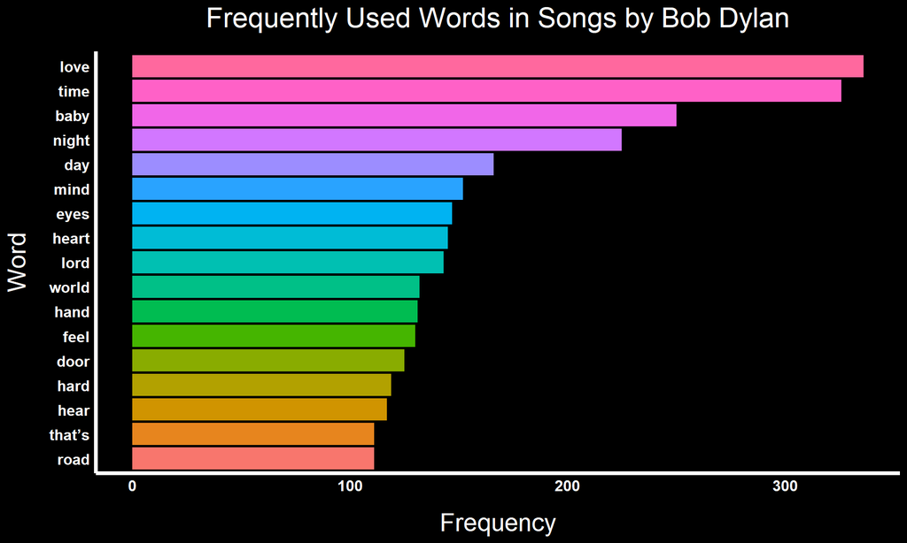

```r
lyrics_graph <-  lyrics %>%
  filter(n > 110) %>%
  mutate(word = reorder(word, n)) %>%
  ggplot(aes(n, word, fill = word)) +
  geom_col(show.legend = FALSE) +
  labs(x = "Frequency", y = "Word", title = "Frequently Used Words in Songs by Bob Dylan") +
  theme(panel.background = element_rect(color = "black", fill = "black"),
        plot.background = element_rect(fill = 'black', colour = 'black'),
        plot.title = element_text(size = rel(2), hjust = 0.5, margin = margin(b = 15, t = 0, r = 0, l = 0), colour = "white"),
        axis.title.y = element_text(margin = margin(r = 15), size = 20, colour = "white"),
        axis.title.x = element_text(margin = margin(t = 15), size = 20, colour = "white"),
        plot.caption = element_text(size = 15),
        panel.grid.major = element_blank(),
        panel.grid.minor = element_blank(),
        axis.text.x = element_text(colour = "white", size = 12, face="bold"),
        axis.text.y = element_text(colour = "white", size = 12, face="bold" ),
        axis.line = element_line(color="white", size = 1.5),
        axis.ticks = element_blank())

lyrics_graph
```

**4.Sentiment Analysis**

```r
#Row-bind the sentiment dataframes
lyrics_sentiment <- lyrics %>%
  inner_join(get_sentiments("afinn")) %>%
  inner_join(get_sentiments("bing"))

#Note that some words who are not sentimental are removed here automatically. These words are words like "eyes", "time", etc.
#Make another column called the sent, which is equal to n * value (weighted frequency)

lyrics_sentiment$sent <- lyrics_sentiment$n * lyrics_sentiment$value
lyrics_sentiment
```

```
## # A tibble: 483 x 5
##    word        n value sentiment  sent
##    <chr>   <int> <dbl> <chr>     <dbl>
##  1 love      336     3 positive   1008
##  2 hard      119    -1 negative   -119
##  3 dead       84    -3 negative   -252
##  4 trouble    75    -2 negative   -150
##  5 broken     66    -1 negative    -66
##  6 wrong      66    -2 negative   -132
##  7 bad        61    -3 negative   -183
##  8 poor       56    -2 negative   -112
##  9 die        55    -3 negative   -165
## 10 sweet      51     2 positive    102
## # ... with 473 more rows
```

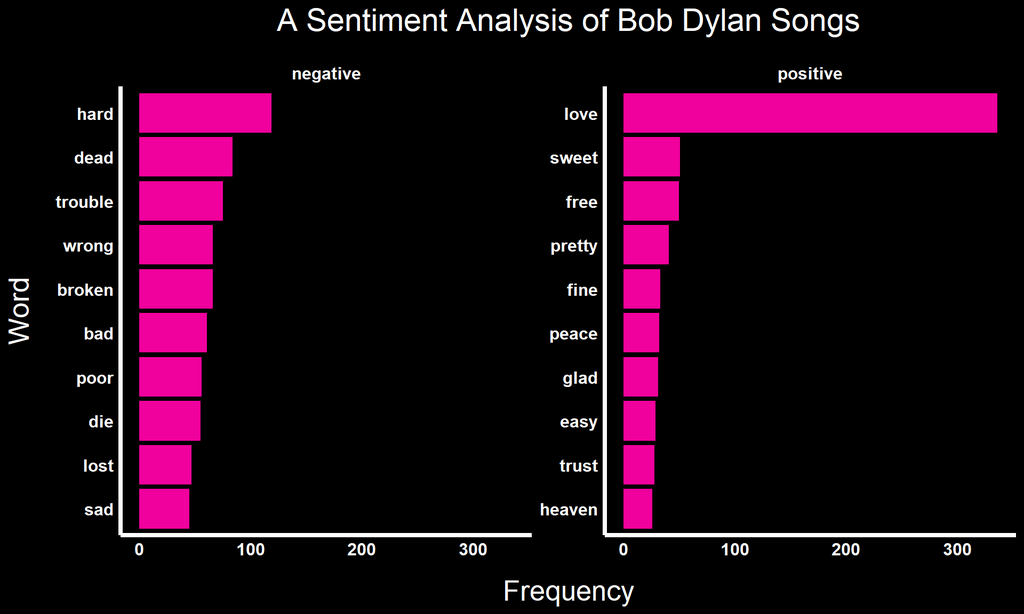

```r
lyrics_sentiment_graph <- lyrics_sentiment %>%
  group_by(sentiment) %>%
  slice_max(n, n = 10) %>%
  ungroup() %>%
  mutate(word = reorder(word, n)) %>%
  ggplot(aes(n, word, fill = sentiment)) +
  geom_col(show.legend = FALSE) +
  facet_wrap(~sentiment, scales = "free_y") +
  labs(x = "Frequency", y = "Word", title = "A Sentiment Analysis of Bob Dylan Songs") +
  theme(panel.background = element_rect(color = "black", fill = "black"),
        plot.background = element_rect(fill = 'black', colour = 'black'),
        plot.title = element_text(size = rel(2), hjust = 0.5, margin = margin(b = 15, t = 0, r = 0, l = 0), colour = "white"),
        axis.title.y = element_text(margin = margin(r = 15), size = 20, colour = "white"),
        axis.title.x = element_text(margin = margin(t = 15), size = 20, colour = "white"),
        plot.caption = element_text(size = 15),
        panel.grid.major = element_blank(),
        panel.grid.minor = element_blank(),
        axis.text.x = element_text(colour = "white", size = 12, face="bold"),
        axis.text.y = element_text(colour = "white", size = 12, face="bold" ),
        axis.line = element_line(color="white", size = 1.5),
        strip.text.x = element_text(size = 12, color = "white", face = "bold"),
        strip.text.y = element_text(size = 12, color = "white", face = "bold"),
        strip.background = element_rect(color = "black", fill = "black"),
        axis.ticks = element_blank()) +
        scale_fill_manual(values= c("#f0009c","#f0009c"))
lyrics_sentiment_graph
```

Let’s check the overall value of the sentiments (i.e Positivity + Negativity of all)

```r
sum(lyrics_sentiment$sent)
```

```
## [1] -1585
```

…Bob seems to be very pessimistic!

**5.Another approach (By the weighted frequencies)**

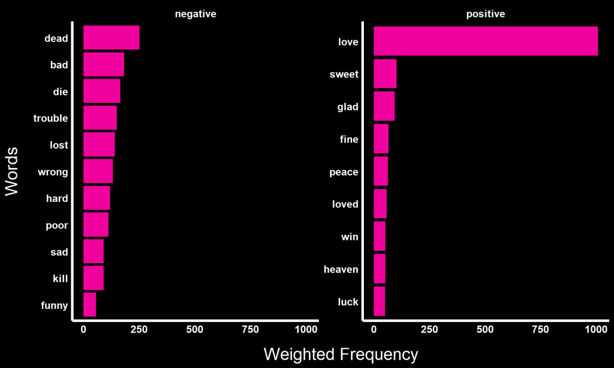

```r
lyrics_sentiment <- lyrics_sentiment[order(lyrics_sentiment$sent),]
negative_outliers <- lyrics_sentiment[1:10,]
lyrics_sentiment <- lyrics_sentiment[order(-lyrics_sentiment$sent),]
positive_outliers <- lyrics_sentiment[1:10,]

outliers <- rbind(negative_outliers, positive_outliers)
outliers$sent <- abs(outliers$sent)

outliers_graph <- outliers %>%
  group_by(sentiment) %>%
  mutate(word = reorder(word, sent)) %>%
  ggplot(aes(sent, word, fill = sentiment)) +
  geom_col(show.legend = FALSE) +
  facet_wrap(~sentiment, scales = "free_y") +
  labs(x = "Weighted Frequency",
       y = "Words") +
  theme(panel.background = element_rect(color = "black", fill = "black"),
        plot.background = element_rect(fill = 'black', colour = 'black'),
        plot.title = element_text(size = rel(2), hjust = 0.5, margin = margin(b = 15, t = 0, r = 0, l = 0), colour = "white"),
        axis.title.y = element_text(margin = margin(r = 15), size = 20, colour = "white"),
        axis.title.x = element_text(margin = margin(t = 15), size = 20, colour = "white"),
        plot.caption = element_text(size = 15),
        panel.grid.major = element_blank(),
        panel.grid.minor = element_blank(),
        axis.text.x = element_text(colour = "white", size = 12, face="bold"),
        axis.text.y = element_text(colour = "white", size = 12, face="bold" ),
        axis.line = element_line(color="white", size = 1.5),
        strip.text.x = element_text(size = 12, color = "white", face = "bold"),
        strip.text.y = element_text(size = 12, color = "white", face = "bold"),
        strip.background = element_rect(color = "black", fill = "black"),
        axis.ticks = element_blank()) +
  scale_fill_manual(values= c("#f0009c","#f0009c"))

outliers_graph
```

Dead & love had the highest weighted frequencies. It is a good coincidence with Tom Waits’ song Dead and Lovely.

**6.Build a WordCloud shaping a star!**

```r
wordcloud <- wordcloud2(lyrics[1:25,], color = "random-light", backgroundColor = "black", fontWeight = "bold", rotateRatio = 0.7,
           shape = "star", ellipticity = 1)

wordcloud
```

[interactive chart not shown]

**7. Create Biagrams**

```r
lyrics_biagram <- dylan_words %>%
  unnest_tokens(bigram, text, token = "ngrams", n = 2) %>%
  count(bigram, sort = TRUE) %>%
  separate(bigram, c("word1", "word2"), sep = " ") %>%
  filter(!word1 %in% stop_words$word) %>%
  filter(!word2 %in% stop_words$word) %>%
  unite(bigram, word1, word2, sep = " ")

lyrics_biagram
```

```
## # A tibble: 9,585 x 2
##    bigram            n
##    <chr>         <int>
##  1 you’re gonna     70
##  2 uh huh           56
##  3 true love        45
##  4 don’t wanna      43
##  5 i’m gonna        37
##  6 ain’t gonna      35
##  7 stop crying      33
##  8 gonna wake       28
##  9 wiggle wiggle    26
## 10 gonna grieve     25
## # ... with 9,575 more rows
```

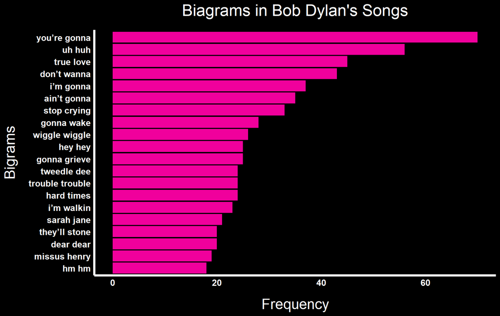

```r
bigrams_graph <- lyrics_biagram[1:20,] %>%
  mutate(bigram = reorder(bigram, n)) %>%
  ggplot(aes(n, bigram, group = 1)) +
  geom_col(show.legend = FALSE, fill = '#f0009c') +
  labs(x = "Frequency", y = "Bigrams", title = "Biagrams in Bob Dylan's Songs") +
  theme(panel.background = element_rect(color = "black", fill = "black"),
        plot.background = element_rect(fill = 'black', colour = 'black'),
        plot.title = element_text(size = rel(2), hjust = 0.5, margin = margin(b = 15, t = 0, r = 0, l = 0), colour = "white"),
        axis.title.y = element_text(margin = margin(r = 15), size = 20, colour = "white"),
        axis.title.x = element_text(margin = margin(t = 15), size = 20, colour = "white"),
        plot.caption = element_text(size = 15),
        panel.grid.major = element_blank(),
        panel.grid.minor = element_blank(),
        axis.text.x = element_text(colour = "white", size = 12, face="bold"),
        axis.text.y = element_text(colour = "white", size = 12, face="bold" ),
        axis.line = element_line(color="white", size = 1.5),
        strip.text.x = element_text(size = 12, color = "white", face = "bold"),
        strip.text.y = element_text(size = 12, color = "white", face = "bold"),
        strip.background = element_rect(color = "black", fill = "black"),
        axis.ticks = element_blank())

bigrams_graph
```

“Sarah Jane” is one of the most used bigrams in Bob Dylan’s songs. We know that she was the first wife of Bob Dylan, later to be called “Sarah Dylan”!

The analysis suggests that the love is one of the main themes in Bob Dylan’s songs, and that these songs are most likely to be pessimistic since the words “dead”, “die”, “trouble”, and the bigrams like “stop crying”, “trouble trouble”, “hard times” occur a lot.